# Problem Set 2

Bridget Antwiwaa

1/31/2022

**Question A: Construct a scatter plot**

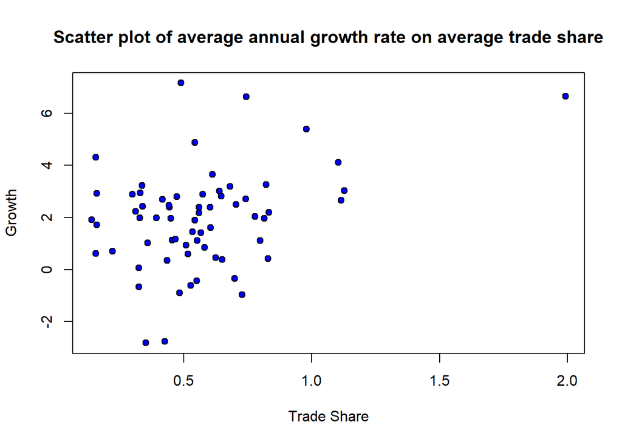

```r
Growth = read.csv(choose.files(), header = T)
plot(x=Growth$tradeshare, y=Growth$growth, xlab = "Trade Share", ylab = "Growth", main = "Scatter plot of average annual growth rate on average trade share", pch= 21, bg="blue")
```

```r
stargazer::stargazer(Growth,type = 'text')
```

```
##
## ==========================================================================
## Statistic     N    Mean    St. Dev.    Min   Pctl(25)  Pctl(75)     Max
## --------------------------------------------------------------------------
## growth        65   1.943     1.897   -2.812    0.838     2.880     7.157
## oil           65   0.000     0.000      0        0         0         0
## rgdp60        65 3,103.785 2,512.657 367.000 1,148.000 5,143.001 9,895.004
## tradeshare    65   0.565     0.289    0.141    0.393     0.682     1.993
## yearsschool   65   3.985     2.542    0.200    1.940     5.560    10.070
## rev_coups     65   0.167     0.225    0.000    0.000     0.267     0.970
## assasinations 65   0.278     0.492    0.000    0.000     0.233     2.467
## --------------------------------------------------------------------------
```

**Question B**

Malta trade share is 1.9926157, and looking at the scatter plot; it looks like Malta is an outlier.

**Question C**

```r
reg1=lm(growth ~ tradeshare, data=Growth)
summary(reg1)
```

```
##
## Call:
## lm(formula = growth ~ tradeshare, data = Growth)
##
## Residuals:
##     Min      1Q  Median      3Q     Max
## -4.3739 -0.8864  0.2329  0.9248  5.3889
##
## Coefficients:
##             Estimate Std. Error t value Pr(>|t|)
## (Intercept)   0.6403     0.4900   1.307  0.19606
## tradeshare    2.3064     0.7735   2.982  0.00407 **
## ---
## Signif. codes:  0 '***' 0.001 '**' 0.01 '*' 0.05 '.' 0.1 ' ' 1
##
## Residual standard error: 1.79 on 63 degrees of freedom
## Multiple R-squared:  0.1237, Adjusted R-squared:  0.1098
## F-statistic: 8.892 on 1 and 63 DF,  p-value: 0.00407
```

```r
reg1$coefficients
```

```
## (Intercept)  tradeshare
##   0.6402653   2.3064337
```

slope is 2.3064337 and intercept is 0.6402653

estimated regression equation: Growth = 0.6402653 + 2.3064337tradeshare

x= 0.5

```r
0.6402653 + 2.3064337*(0.5)
```

```
## [1] 1.793482
```

x= 1.0

```r
0.6402653 + 2.3064337*(1.0)
```

```
## [1] 2.946699
```

**Question D**

```r
Growth.remove.Malta=Growth[-35,]
reg2=lm(growth ~ tradeshare, Growth.remove.Malta)
summary(reg2)
```

```
##
## Call:
## lm(formula = growth ~ tradeshare, data = Growth.remove.Malta)
##
## Residuals:
##     Min      1Q  Median      3Q     Max
## -4.4247 -0.9383  0.2091  0.9265  5.3776
##
## Coefficients:
##             Estimate Std. Error t value Pr(>|t|)
## (Intercept)   0.9574     0.5804   1.650   0.1041
## tradeshare    1.6809     0.9874   1.702   0.0937 .
## ---
## Signif. codes:  0 '***' 0.001 '**' 0.01 '*' 0.05 '.' 0.1 ' ' 1
##
## Residual standard error: 1.789 on 62 degrees of freedom
## Multiple R-squared:  0.04466,    Adjusted R-squared:  0.02925
## F-statistic: 2.898 on 1 and 62 DF,  p-value: 0.09369
```

```r
reg2$coefficients
```

```
## (Intercept)  tradeshare
##   0.9574107   1.6809047
```

slope is 1.6809047 and intercept is 0.9574107

estimated regression equation:Growth = 0.9574107 + 1.6809047tradeshare

y= 0.5

```r
0.9574107 + 1.6809047*(0.5)
```

```
## [1] 1.797863
```

Y= 1.0

```r
0.9574107 + 1.6809047*(1.0)
```

```
## [1] 2.638315
```

**Question E**

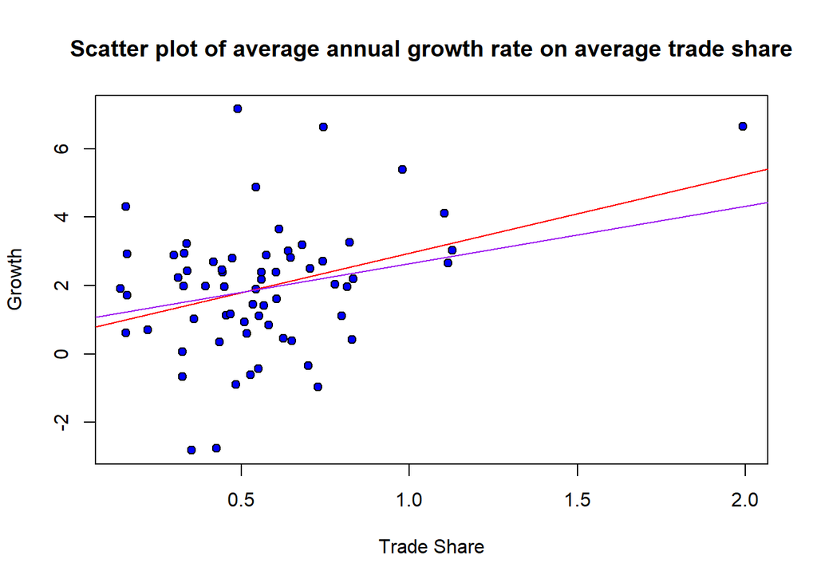

```r
plot(x=Growth$tradeshare, y=Growth$growth, xlab = "Trade Share", ylab = "Growth", main = "Scatter plot of average annual growth rate on average trade share", pch= 21, bg="blue")
abline(lm(growth ~ tradeshare, data=Growth), col='red')
abline(lm(growth ~ tradeshare, Growth.remove.Malta), col='purple')
```

Because Malta is an outlier since its number is vast to other countries. Therefore, the outlier changed the outcome of the data, and once removed, the slope got smaller changing the shape of the regression.

**Question F**

Malta should be excluded from the data because Malta is an outlier. Outliers increase the variability in the data, which, as a result, decreases the statistical power of the data. However, if we decide to use Malta in the data, we can weigh it using weighted mean, variance, etc. Malta is a small independent nation located about 60mi south of Sicily in southern Europe. Malta has a large trade share because it is a freight transport site. Goods immediately transported to Malta are exported directly to other countries. Also, their economy depends on foreign trade.